# Gene expression heatmaps - practice

Rmd to create heatmaps of differentially expressed gene lists. Two DEG lists (with gene counts):  
1. Temperature DEG and gene count list: https://raw.githubusercontent.com/RobertsLab/paper-crab/master/analyses/temp_DEGlist-counts.tab 2. Infection DEG and gene count list: https://raw.githubusercontent.com/RobertsLab/project-crab/master/analyses/2019-infection-degs_genecounts.csv

ALSO –> after those two heatmaps, I’m making a TON of heatmaps from the 2020 Genewiz individual RNA seq data.

### Set up R Markdown document

## Install packages:

(uncomment “install.packages(”pheatmap“)” if you need to install it)

```r
#install.packages("pheatmap")
library(pheatmap)
```

```r
library(dplyr)
#install.packages("RColorBrewer")
library(RColorBrewer)
```

# Temperature comparison (elevated vs decreased) heatmap

```r
heatmapGreens <- RColorBrewer::brewer.pal(9, "Greens")
```

### Read in temperature DEG list with gene counts table (423 rows)

```r
temp_counts <- read.delim("../analyses/temp_DEGlist-counts-log.txt", sep = '\t')
head(temp_counts)
```

```
##                 Trinity_ID   baseMean log2FoldChange     lfcSE      stat
## 1     TRINITY_DN1_c0_g1_i3  1527.9064     -0.9307566 0.1596984 -5.828216
## 2 TRINITY_DN10098_c0_g1_i2   427.5377     -0.9505347 0.2437734 -3.899255
## 3  TRINITY_DN1016_c0_g1_i1   157.8117     -2.1808200 0.4256654 -5.123320
## 4  TRINITY_DN1020_c0_g1_i1   588.7443      1.3741964 0.3815273  3.601830
## 5 TRINITY_DN10318_c0_g1_i1  1579.3697     -0.5605904 0.1662810 -3.371344
## 6  TRINITY_DN1050_c0_g1_i1 44107.5277     -0.4868810 0.1625710 -2.994882
##         pvalue        padj X380822_cold X380823_cold X380824_warm X380825_warm
## 1 0.0000000056 0.000001400         1764         1822         1288         1119
## 2 0.0000965000 0.004582470          544          465          347          320
## 3 0.0000003000 0.000036700          244          219           80           51
## 4 0.0003159850 0.009601251          208          377          920         1019
## 5 0.0007480240 0.017622738         1778         1592         1566         1356
## 6 0.0027455140 0.042490214        49110        43060        39126        44671
##   X380822_cold_log X380823_cold_log X380824_warm_log X380825_warm_log
## 1         3.246745         3.260787         3.110253         3.049218
## 2         2.736397         2.668386         2.541579         2.506505
## 3         2.389166         2.342423         1.908485         1.716003
## 4         2.320146         2.577492         2.964260         3.008600
## 5         3.250176         3.202216         3.195069         3.132580
## 6         4.691179         4.634084         4.592477         4.650035
```

Subset just the Trinity_ID column and the gene count sample columns (log +1 transformed):

```r
matrix_temp <- select(temp_counts, Trinity_ID, X380822_cold_log, X380823_cold_log, X380824_warm_log, X380825_warm_log)
head(matrix_temp)
```

```
##                 Trinity_ID X380822_cold_log X380823_cold_log X380824_warm_log
## 1     TRINITY_DN1_c0_g1_i3         3.246745         3.260787         3.110253
## 2 TRINITY_DN10098_c0_g1_i2         2.736397         2.668386         2.541579
## 3  TRINITY_DN1016_c0_g1_i1         2.389166         2.342423         1.908485
## 4  TRINITY_DN1020_c0_g1_i1         2.320146         2.577492         2.964260
## 5 TRINITY_DN10318_c0_g1_i1         3.250176         3.202216         3.195069
## 6  TRINITY_DN1050_c0_g1_i1         4.691179         4.634084         4.592477
##   X380825_warm_log
## 1         3.049218
## 2         2.506505
## 3         1.716003
## 4         3.008600
## 5         3.132580
## 6         4.650035
```

Set Trinity_ID as row names:

```r
rownames(matrix_temp) <- matrix_temp$Trinity_ID #set Trinity_ID as rownames
matrix_temp.heatmap <- matrix_temp[,-1] #remove redundant column
head(matrix_temp.heatmap)
```

```
##                          X380822_cold_log X380823_cold_log X380824_warm_log
## TRINITY_DN1_c0_g1_i3             3.246745         3.260787         3.110253
## TRINITY_DN10098_c0_g1_i2         2.736397         2.668386         2.541579
## TRINITY_DN1016_c0_g1_i1          2.389166         2.342423         1.908485
## TRINITY_DN1020_c0_g1_i1          2.320146         2.577492         2.964260
## TRINITY_DN10318_c0_g1_i1         3.250176         3.202216         3.195069
## TRINITY_DN1050_c0_g1_i1          4.691179         4.634084         4.592477
##                          X380825_warm_log
## TRINITY_DN1_c0_g1_i3             3.049218
## TRINITY_DN10098_c0_g1_i2         2.506505
## TRINITY_DN1016_c0_g1_i1          1.716003
## TRINITY_DN1020_c0_g1_i1          3.008600
## TRINITY_DN10318_c0_g1_i1         3.132580
## TRINITY_DN1050_c0_g1_i1          4.650035
```

Subset genes of interest (for practice, just picking random ones)

```r
#include_list <- c("TRINITY_DN169_c0_g1_i11", "TRINITY_DN983_c0_g1_i3", "TRINITY_DN25158_c34_g1_i1", "TRINITY_DN5806_c0_g1_i1")
#matrix_temp.heatmap.sub <- matrix_temp.heatmap[include_list, ]
#matrix_temp.heatmap.sub
```

Create heatmap for temperature DEG list:

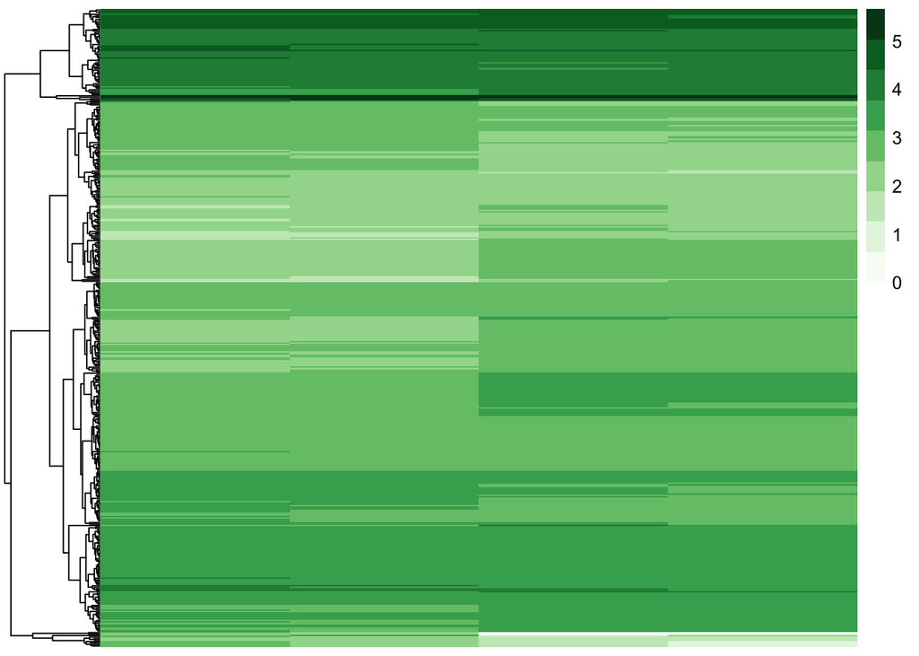

```r
pheatmap(matrix_temp.heatmap, cluster_row = TRUE, cluster_cols = FALSE, clustering_distance_rows = "euclidean", clustering_method = "average", show_rownames = FALSE, show_colnames = FALSE, treeheight_col = 80, legend = TRUE, color = heatmapGreens, fontsize_col = 20, fontsize_row = 12)
```

# Infection comparison heatmap

Heatmap color palette:

```r
heatmapOranges <- RColorBrewer::brewer.pal(9, "Oranges")
```

### Read in infection status DEG list with gene counts table (772 rows)

```r
infect_counts <- read.delim("../../project-crab/analyses/2019-infection-degs_genecounts.csv", sep = ',')
head(infect_counts)
```

```
##                 Trinity_ID baseMean log2FoldChange    lfcSE     stat   pvalue
## 1  TRINITY_DN1003_c0_g1_i4 26.88821       8.099741 1.916722 4.225829 2.38e-05
## 2 TRINITY_DN10053_c0_g1_i1 40.44398       8.688934 1.791345 4.850508 1.23e-06
## 3 TRINITY_DN10053_c0_g2_i1 70.89865       5.867618 1.169757 5.016099 5.27e-07
## 4 TRINITY_DN10062_c0_g1_i1 24.47404       7.964747 1.994940 3.992474 6.54e-05
## 5 TRINITY_DN10074_c0_g1_i1 33.58529       8.421178 1.868964 4.505801 6.61e-06
## 6 TRINITY_DN10074_c0_g2_i1 43.46756       8.793359 1.810592 4.856620 1.19e-06
##          padj infected_12 uninfected_12 infected_26 uninfected_26
## 1 0.000871787     68.3703             0     51.8618             0
## 2 0.000061000    111.0000             0     71.0000             0
## 3 0.000028800    208.0000             5    109.0000             0
## 4 0.002205570     78.1523             0     33.8732             0
## 5 0.000276662    103.0000             0     50.0000             0
## 6 0.000059400    139.0000             0     60.0000             0
```

Subset just the Trinity_ID column and the gene count sample columns:

```r
matrix_infect <- select(infect_counts, Trinity_ID, infected_12, uninfected_12, infected_26, uninfected_26)
head(matrix_infect)
```

```
##                 Trinity_ID infected_12 uninfected_12 infected_26 uninfected_26
## 1  TRINITY_DN1003_c0_g1_i4     68.3703             0     51.8618             0
## 2 TRINITY_DN10053_c0_g1_i1    111.0000             0     71.0000             0
## 3 TRINITY_DN10053_c0_g2_i1    208.0000             5    109.0000             0
## 4 TRINITY_DN10062_c0_g1_i1     78.1523             0     33.8732             0
## 5 TRINITY_DN10074_c0_g1_i1    103.0000             0     50.0000             0
## 6 TRINITY_DN10074_c0_g2_i1    139.0000             0     60.0000             0
```

Set Trinity_ID as row names:

```r
rownames(matrix_infect) <- matrix_infect$Trinity_ID #set Trinity_ID as rownames
matrix_infect.heatmap <- matrix_infect[,-1] #remove redundant column
head(matrix_infect.heatmap)
```

```
##                          infected_12 uninfected_12 infected_26 uninfected_26
## TRINITY_DN1003_c0_g1_i4      68.3703             0     51.8618             0
## TRINITY_DN10053_c0_g1_i1    111.0000             0     71.0000             0
## TRINITY_DN10053_c0_g2_i1    208.0000             5    109.0000             0
## TRINITY_DN10062_c0_g1_i1     78.1523             0     33.8732             0
## TRINITY_DN10074_c0_g1_i1    103.0000             0     50.0000             0
## TRINITY_DN10074_c0_g2_i1    139.0000             0     60.0000             0
```

Subset genes of interest (for practice, just picking random ones)

```r
#include_list <- c("TRINITY_DN1003_c0_g1_i4", "TRINITY_DN7071_c0_g1_i1", "TRINITY_DN1796_c0_g1_i1", "TRINITY_DN1796_c0_g1_i1")
#matrix_infect.heatmap.sub <- matrix_infect.heatmap[include_list, ]
#matrix_infect.heatmap.sub
```

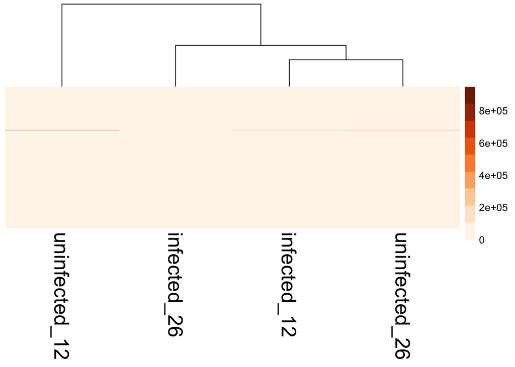

```r
pheatmap(matrix_infect.heatmap, cluster_row = FALSE, cluster_cols = TRUE, clustering_distance_rows = "euclidean", clustering_method = "average", show_rownames = FALSE, show_colnames = TRUE, treeheight_col = 80, legend = TRUE, color = heatmapOranges, fontsize_col = 20, fontsize_row = 12)
```

# HEAT MAPS FOR INDIVIDUAL CRAB RNASEQ DATA

Just making a ton to see if anything is interesting

upload individual RNAseq gene count data (2020 Genewiz samples): with log+1 transformation

```r
master_individual_counts <- read.delim("../analyses/individual-crab-isoform-counts-log.txt", sep = '\t')
head(master_individual_counts)
```

```
##                          X X294_quant X254_quant X280_quant X485_quant
## 1  TRINITY_DN5772_c0_g1_i1          0          0      0.000          0
## 2  TRINITY_DN2201_c0_g1_i1          5          0      5.823          0
## 3  TRINITY_DN4656_c0_g1_i1         19         36      4.000         12
## 4  TRINITY_DN7591_c0_g1_i1         16          3      2.000          1
## 5  TRINITY_DN6285_c0_g1_i4          0          0      0.000          4
## 6 TRINITY_DN28918_c0_g1_i1          0          0      0.000          0
##   X481_quant X173_quant X222_quant X151_quant X272_quant X132_quant X127_quant
## 1          0          0          0          0          0          0          0
## 2          0          0          5          0          0          0          0
## 3          8         74          8         53          0          7         18
## 4         15          0         11         17          0          0         41
## 5          0          0          0          0          0          0          0
## 6          1          0          0          0          0          0          1
##   X73_quant X427_quant X118_quant X334_quant X349_quant X425_quant X178_quant
```

[output cut: 48 more lines]

Pull out column Trinity IDs and all individual samples that have _log in column name:

```r
matrix_individ_log <- select(master_individual_counts, X, X294_quant_log, X254_quant_log, X280_quant_log, X485_quant_log, X481_quant_log, X173_quant_log, X222_quant_log, X151_quant_log, X272_quant_log, X132_quant_log, X127_quant_log, X73_quant_log, X427_quant_log, X118_quant_log, X334_quant_log, X349_quant_log, X425_quant_log, X178_quant_log, X72_quant_log, X463_quant_log, X221_quant_log, X445_quant_log, X359_quant_log, X113_quant_log)
head(matrix_individ_log)
```

```
##                          X X294_quant_log X254_quant_log X280_quant_log
## 1  TRINITY_DN5772_c0_g1_i1      0.0000000       0.000000      0.0000000
## 2  TRINITY_DN2201_c0_g1_i1      0.7781512       0.000000      0.8339754
## 3  TRINITY_DN4656_c0_g1_i1      1.3010300       1.568202      0.6989700
## 4  TRINITY_DN7591_c0_g1_i1      1.2304489       0.602060      0.4771213
## 5  TRINITY_DN6285_c0_g1_i4      0.0000000       0.000000      0.0000000
## 6 TRINITY_DN28918_c0_g1_i1      0.0000000       0.000000      0.0000000
##   X485_quant_log X481_quant_log X173_quant_log X222_quant_log X151_quant_log
## 1       0.000000      0.0000000       0.000000      0.0000000       0.000000
## 2       0.000000      0.0000000       0.000000      0.7781512       0.000000
## 3       1.113943      0.9542425       1.875061      0.9542425       1.732394
## 4       0.301030      1.2041200       0.000000      1.0791812       1.255273
## 5       0.698970      0.0000000       0.000000      0.0000000       0.000000
## 6       0.000000      0.3010300       0.000000      0.0000000       0.000000
##   X272_quant_log X132_quant_log X127_quant_log X73_quant_log X427_quant_log
```

[output cut: 27 more lines]

Rename columns based on crab ID along with sample day (example: A_0, A_2, A_17) Tab 3 in this google doc give GeneWiz IDs for the individual crabs (A-I) https://docs.google.com/spreadsheets/d/1d17yg5F5gKKC66O8QkTIlPxljJeuX7ZsG46pkBr1lNQ/edit#gid=848044428

```r
colnames(matrix_individ_log) <- c("Trinity_ID", "CrabH_2", "CrabE_2", "CrabI_2", "CrabC_17", "CrabB_17", "CrabG_0", "CrabF_2", "CrabE_0", "CrabG_2", "CrabC_0", "CrabI_0", "CrabD_0", "CrabD_17", "CrabB_0", "CrabC_2", "CrabB_2", "CrabF_17", "CrabA_0", "CrabH_0", "CrabA_17", "CrabD_2", "CrabE_17", "CrabA_2", "CrabF_0")
head(matrix_individ_log)
```

```
##                 Trinity_ID   CrabH_2  CrabE_2   CrabI_2 CrabC_17  CrabB_17
## 1  TRINITY_DN5772_c0_g1_i1 0.0000000 0.000000 0.0000000 0.000000 0.0000000
## 2  TRINITY_DN2201_c0_g1_i1 0.7781512 0.000000 0.8339754 0.000000 0.0000000
## 3  TRINITY_DN4656_c0_g1_i1 1.3010300 1.568202 0.6989700 1.113943 0.9542425
## 4  TRINITY_DN7591_c0_g1_i1 1.2304489 0.602060 0.4771213 0.301030 1.2041200
## 5  TRINITY_DN6285_c0_g1_i4 0.0000000 0.000000 0.0000000 0.698970 0.0000000
## 6 TRINITY_DN28918_c0_g1_i1 0.0000000 0.000000 0.0000000 0.000000 0.3010300
##    CrabG_0   CrabF_2  CrabE_0 CrabG_2 CrabC_0  CrabI_0 CrabD_0 CrabD_17
## 1 0.000000 0.0000000 0.000000       0 0.00000 0.000000       0        0
## 2 0.000000 0.7781512 0.000000       0 0.00000 0.000000       0        0
## 3 1.875061 0.9542425 1.732394       0 0.90309 1.278754       0        0
## 4 0.000000 1.0791812 1.255273       0 0.00000 1.623249       0        0
## 5 0.000000 0.0000000 0.000000       0 0.00000 0.000000       0        0
## 6 0.000000 0.0000000 0.000000       0 0.00000 0.301030       0        0
##     CrabB_0 CrabC_2 CrabB_2 CrabF_17   CrabA_0 CrabH_0 CrabA_17 CrabD_2
## 1 0.0000000 0.00000       0        0 0.0000000 0.00000        0       0
## 2 0.0000000 0.00000       0        0 0.0000000 0.00000        0       0
## 3 0.6989700 0.60206       0        0 1.5797836 0.90309        0       0
## 4 0.4771213 0.00000       0        0 0.6020600 0.00000        0       0
## 5 0.0000000 0.00000       0        0 0.0000000 0.00000        0       0
## 6 0.0000000 0.00000       0        0 0.4771213 0.00000        0       0
##    CrabE_17  CrabA_2  CrabF_0
## 1 0.0000000 0.602060 0.000000
## 2 1.9084850 0.000000 1.469071
## 3 1.3222193 1.556303 1.176091
## 4 1.5910646 1.414973 1.568202
## 5 0.8417348 0.000000 0.000000
## 6 0.0000000 0.000000 0.000000
```

# Heatmap for crabs A, B, and C over time

CrabA 0, 2, 17 (infected ambient) CrabB 0, 2, 17 (infected ambient) CrabC 0, 2, 17 (infected ambient)

Subset the Trinity IDs and the counts for those samples:

```r
ABC <- select(matrix_individ_log, Trinity_ID, CrabA_0, CrabA_2, CrabA_17, CrabB_0, CrabB_2, CrabB_17, CrabC_0, CrabC_2, CrabC_17)
head(ABC)
```

```
##                 Trinity_ID   CrabA_0  CrabA_2 CrabA_17   CrabB_0 CrabB_2
## 1  TRINITY_DN5772_c0_g1_i1 0.0000000 0.602060        0 0.0000000       0
## 2  TRINITY_DN2201_c0_g1_i1 0.0000000 0.000000        0 0.0000000       0
## 3  TRINITY_DN4656_c0_g1_i1 1.5797836 1.556303        0 0.6989700       0
## 4  TRINITY_DN7591_c0_g1_i1 0.6020600 1.414973        0 0.4771213       0
## 5  TRINITY_DN6285_c0_g1_i4 0.0000000 0.000000        0 0.0000000       0
## 6 TRINITY_DN28918_c0_g1_i1 0.4771213 0.000000        0 0.0000000       0
##    CrabB_17 CrabC_0 CrabC_2 CrabC_17
## 1 0.0000000 0.00000 0.00000 0.000000
## 2 0.0000000 0.00000 0.00000 0.000000
## 3 0.9542425 0.90309 0.60206 1.113943
## 4 1.2041200 0.00000 0.00000 0.301030
## 5 0.0000000 0.00000 0.00000 0.698970
## 6 0.3010300 0.00000 0.00000 0.000000
```

Set Trinity_ID as row names:

```r
rownames(ABC) <- ABC$Trinity_ID #set Trinity IDs as rownames
ABC.heatmap <- ABC[,-1] #remove redundant column
head(ABC.heatmap)
```

```
##                            CrabA_0  CrabA_2 CrabA_17   CrabB_0 CrabB_2
## TRINITY_DN5772_c0_g1_i1  0.0000000 0.602060        0 0.0000000       0
## TRINITY_DN2201_c0_g1_i1  0.0000000 0.000000        0 0.0000000       0
## TRINITY_DN4656_c0_g1_i1  1.5797836 1.556303        0 0.6989700       0
## TRINITY_DN7591_c0_g1_i1  0.6020600 1.414973        0 0.4771213       0
## TRINITY_DN6285_c0_g1_i4  0.0000000 0.000000        0 0.0000000       0
## TRINITY_DN28918_c0_g1_i1 0.4771213 0.000000        0 0.0000000       0
##                           CrabB_17 CrabC_0 CrabC_2 CrabC_17
## TRINITY_DN5772_c0_g1_i1  0.0000000 0.00000 0.00000 0.000000
## TRINITY_DN2201_c0_g1_i1  0.0000000 0.00000 0.00000 0.000000
## TRINITY_DN4656_c0_g1_i1  0.9542425 0.90309 0.60206 1.113943
## TRINITY_DN7591_c0_g1_i1  1.2041200 0.00000 0.00000 0.301030
## TRINITY_DN6285_c0_g1_i4  0.0000000 0.00000 0.00000 0.698970
## TRINITY_DN28918_c0_g1_i1 0.3010300 0.00000 0.00000 0.000000
```

Open the annotated version of the individual crab isoform matrix to find genes of interest (compared to list of stress response genes)

```r
annotated <- read.delim("../analyses/individual-crab-counts-annot.tab", sep = '\t')
head(annotated)
```

```
##                 Trinity_ID X294_quant X254_quant X280_quant X485_quant
## 1  TRINITY_DN5772_c0_g1_i1          0          0      0.000          0
## 2  TRINITY_DN2201_c0_g1_i1          5          0      5.823          0
## 3  TRINITY_DN4656_c0_g1_i1         19         36      4.000         12
## 4  TRINITY_DN7591_c0_g1_i1         16          3      2.000          1
## 5  TRINITY_DN6285_c0_g1_i4          0          0      0.000          4
## 6 TRINITY_DN28918_c0_g1_i1          0          0      0.000          0
##   X481_quant X173_quant X222_quant X151_quant X272_quant X132_quant X127_quant
## 1          0          0          0          0          0          0          0
## 2          0          0          5          0          0          0          0
## 3          8         74          8         53          0          7         18
## 4         15          0         11         17          0          0         41
## 5          0          0          0          0          0          0          0
## 6          1          0          0          0          0          0          1
##   X73_quant X427_quant X118_quant X334_quant X349_quant X425_quant X178_quant
```

[output cut: 69 more lines]

Subset some genes (cross-references with stress response gene list): TRINITY_DN3510_c0_g1_i1 DnaJ homolog subfamily B member 4 (protein folding [GO:0006457]; response to heat [GO:0009408];)

TRINITY_DN1520_c0_g1_i1 HSP 90-beta (response to stress and lots of other stuff)

TRINITY_DN3772_c0_g1_i1 Heat shock protein 75 kDa, mitochondrial (HSP 75) (TNFR-associated protein 1) response to stress [GO:0006950]; extracellular exosome [GO:0070062]; negative regulation of cellular respiration [GO:1901856]; negative regulation of intrinsic apoptotic signaling pathway in response to hydrogen peroxide [GO:1903751]; response to stress [GO:0006950];

```r
include_list <- c("TRINITY_DN3510_c0_g1_i1", "TRINITY_DN745_c3_g2_i2", "TRINITY_DN1520_c0_g1_i1", "TRINITY_DN3772_c0_g1_i1")
ABC.heatmap.sub <- ABC.heatmap[include_list, ]
ABC.heatmap.sub
```

```
##                          CrabA_0  CrabA_2 CrabA_17  CrabB_0  CrabB_2 CrabB_17
## TRINITY_DN3510_c0_g1_i1 3.458184 3.250420 0.602060 2.240549 0.301030 2.656098
## TRINITY_DN745_c3_g2_i2  2.999982 3.698138 1.171931 2.746697 1.176091 4.078123
## TRINITY_DN1520_c0_g1_i1 3.462248 3.428459 0.602060 2.781755 0.000000 2.655138
## TRINITY_DN3772_c0_g1_i1 1.518514 2.290035 0.000000 1.146128 0.301030 1.799341
##                          CrabC_0  CrabC_2 CrabC_17
## TRINITY_DN3510_c0_g1_i1 2.980912 2.049218 3.145818
## TRINITY_DN745_c3_g2_i2  3.622676 3.124134 4.038180
## TRINITY_DN1520_c0_g1_i1 3.259116 2.624282 2.647383
## TRINITY_DN3772_c0_g1_i1 1.146128 0.000000 1.698970
```

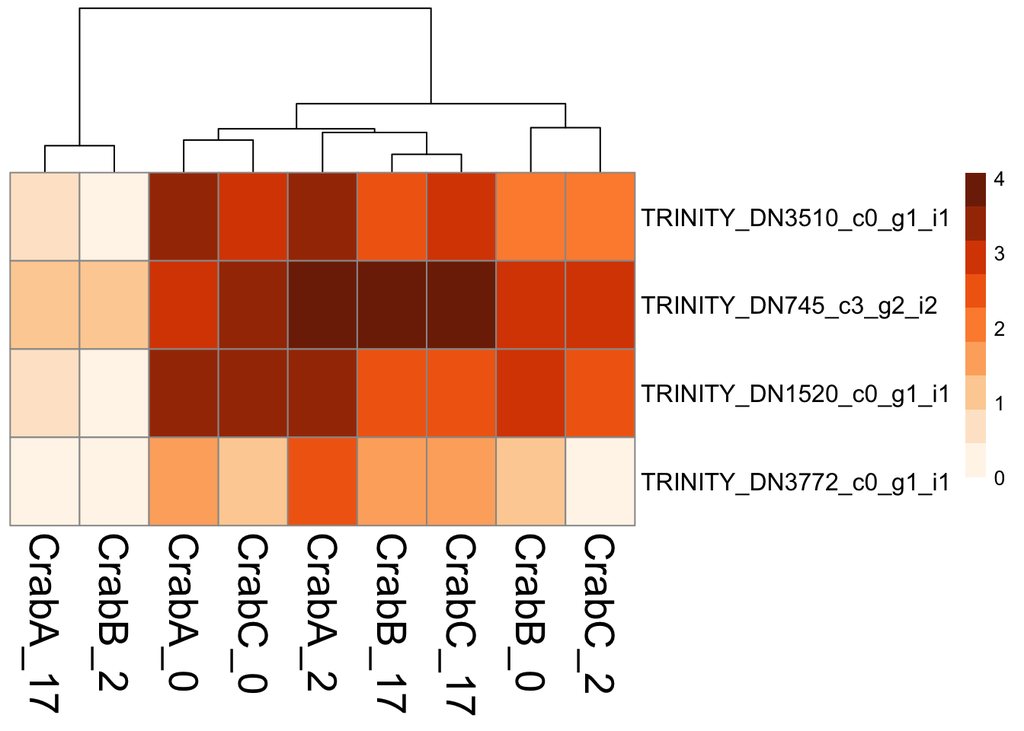

```r
pheatmap(ABC.heatmap.sub, cluster_row = FALSE, cluster_cols = TRUE, clustering_distance_rows = "euclidean", clustering_method = "average", show_rownames = TRUE, show_colnames = TRUE, treeheight_col = 80, legend = TRUE, color = heatmapOranges, fontsize_col = 20, fontsize_row = 12)
```

# HEAT MAPS FOR COMPARING CRAB D AND E

Comparing D and E over time Crab D –> uninfected, decreased temp Crab E –> infected, decreased temp

```r
DE <- select(matrix_individ_log, Trinity_ID, CrabD_0, CrabD_2, CrabD_17, CrabE_0, CrabE_2, CrabE_17, CrabE_0, CrabE_2, CrabE_17)
head(DE)
```

```
##                 Trinity_ID CrabD_0 CrabD_2 CrabD_17  CrabE_0  CrabE_2  CrabE_17
## 1  TRINITY_DN5772_c0_g1_i1       0       0        0 0.000000 0.000000 0.0000000
## 2  TRINITY_DN2201_c0_g1_i1       0       0        0 0.000000 0.000000 1.9084850
## 3  TRINITY_DN4656_c0_g1_i1       0       0        0 1.732394 1.568202 1.3222193
## 4  TRINITY_DN7591_c0_g1_i1       0       0        0 1.255273 0.602060 1.5910646
## 5  TRINITY_DN6285_c0_g1_i4       0       0        0 0.000000 0.000000 0.8417348
## 6 TRINITY_DN28918_c0_g1_i1       0       0        0 0.000000 0.000000 0.0000000
```

Set Trinity_ID as row names:

```r
rownames(DE) <- DE$Trinity_ID #set Trinity IDs as rownames
DE.heatmap <- DE[,-1] #remove redundant column
head(DE.heatmap)
```

```
##                          CrabD_0 CrabD_2 CrabD_17  CrabE_0  CrabE_2  CrabE_17
## TRINITY_DN5772_c0_g1_i1        0       0        0 0.000000 0.000000 0.0000000
## TRINITY_DN2201_c0_g1_i1        0       0        0 0.000000 0.000000 1.9084850
## TRINITY_DN4656_c0_g1_i1        0       0        0 1.732394 1.568202 1.3222193
## TRINITY_DN7591_c0_g1_i1        0       0        0 1.255273 0.602060 1.5910646
## TRINITY_DN6285_c0_g1_i4        0       0        0 0.000000 0.000000 0.8417348
## TRINITY_DN28918_c0_g1_i1       0       0        0 0.000000 0.000000 0.0000000
```

```r
include_list <- c("TRINITY_DN3510_c0_g1_i1", "TRINITY_DN745_c3_g2_i2", "TRINITY_DN1520_c0_g1_i1", "TRINITY_DN3772_c0_g1_i1")
DE.heatmap.sub <- DE.heatmap[include_list, ]
DE.heatmap.sub
```

```
##                           CrabD_0  CrabD_2  CrabD_17  CrabE_0  CrabE_2 CrabE_17
## TRINITY_DN3510_c0_g1_i1 0.4771213 2.683947 0.3010300 3.594503 3.156246 2.913814
## TRINITY_DN745_c3_g2_i2  1.3906525 3.613462 0.9558801 3.342370 3.207700 3.935353
## TRINITY_DN1520_c0_g1_i1 1.5682017 2.848805 0.3010300 3.371253 2.870989 2.938520
## TRINITY_DN3772_c0_g1_i1 0.0000000 0.000000 0.0000000 2.478566 1.591065 2.143015
```

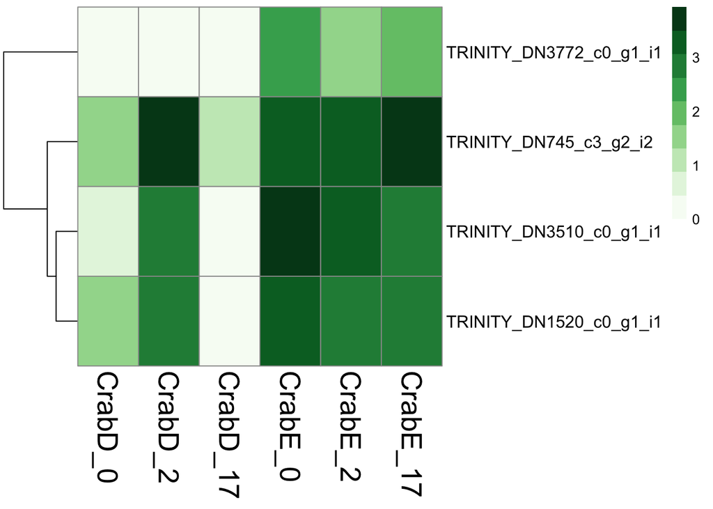

```r
pheatmap(DE.heatmap.sub, cluster_row = TRUE, cluster_cols = FALSE, clustering_distance_rows = "euclidean", clustering_method = "average", show_rownames = TRUE, show_colnames = TRUE, treeheight_col = 80, legend = TRUE, color = heatmapGreens, fontsize_col = 20, fontsize_row = 12)
```

# Heatmap for crabs G, H, and I across time

Crab G - infected elevated Crab H - infected elevated Crab I - infected elevated

```r
GHI <- select(matrix_individ_log, Trinity_ID, CrabG_0, CrabG_2, CrabH_0, CrabH_2, CrabI_0, CrabI_2)
head(GHI)
```

```
##                 Trinity_ID  CrabG_0 CrabG_2 CrabH_0   CrabH_2  CrabI_0
## 1  TRINITY_DN5772_c0_g1_i1 0.000000       0 0.00000 0.0000000 0.000000
## 2  TRINITY_DN2201_c0_g1_i1 0.000000       0 0.00000 0.7781512 0.000000
## 3  TRINITY_DN4656_c0_g1_i1 1.875061       0 0.90309 1.3010300 1.278754
## 4  TRINITY_DN7591_c0_g1_i1 0.000000       0 0.00000 1.2304489 1.623249
## 5  TRINITY_DN6285_c0_g1_i4 0.000000       0 0.00000 0.0000000 0.000000
## 6 TRINITY_DN28918_c0_g1_i1 0.000000       0 0.00000 0.0000000 0.301030
##     CrabI_2
## 1 0.0000000
## 2 0.8339754
## 3 0.6989700
## 4 0.4771213
## 5 0.0000000
## 6 0.0000000
```

Set Trinity_ID as row names:

```r
rownames(GHI) <- GHI$Trinity_ID #set Trinity IDs as rownames
GHI.heatmap <- GHI[,-1] #remove redundant column
head(GHI.heatmap)
```

```
##                           CrabG_0 CrabG_2 CrabH_0   CrabH_2  CrabI_0   CrabI_2
## TRINITY_DN5772_c0_g1_i1  0.000000       0 0.00000 0.0000000 0.000000 0.0000000
## TRINITY_DN2201_c0_g1_i1  0.000000       0 0.00000 0.7781512 0.000000 0.8339754
## TRINITY_DN4656_c0_g1_i1  1.875061       0 0.90309 1.3010300 1.278754 0.6989700
## TRINITY_DN7591_c0_g1_i1  0.000000       0 0.00000 1.2304489 1.623249 0.4771213
## TRINITY_DN6285_c0_g1_i4  0.000000       0 0.00000 0.0000000 0.000000 0.0000000
## TRINITY_DN28918_c0_g1_i1 0.000000       0 0.00000 0.0000000 0.301030 0.0000000
```

```r
include_list <- c("TRINITY_DN3510_c0_g1_i1", "TRINITY_DN745_c3_g2_i2", "TRINITY_DN1520_c0_g1_i1", "TRINITY_DN3772_c0_g1_i1")
GHI.heatmap.sub <- GHI.heatmap[include_list, ]
GHI.heatmap.sub
```

```
##                          CrabG_0   CrabG_2  CrabH_0  CrabH_2  CrabI_0  CrabI_2
## TRINITY_DN3510_c0_g1_i1 2.225309 2.6464037 1.763428 3.317018 3.498311 2.630428
## TRINITY_DN745_c3_g2_i2  2.699814 2.8302331 2.587535 3.500937 3.240947 2.792190
## TRINITY_DN1520_c0_g1_i1 2.952308 2.8055009 2.767898 3.057666 3.546296 2.849419
## TRINITY_DN3772_c0_g1_i1 0.301030 0.9542425 0.698970 2.404834 2.315970 1.968483
```

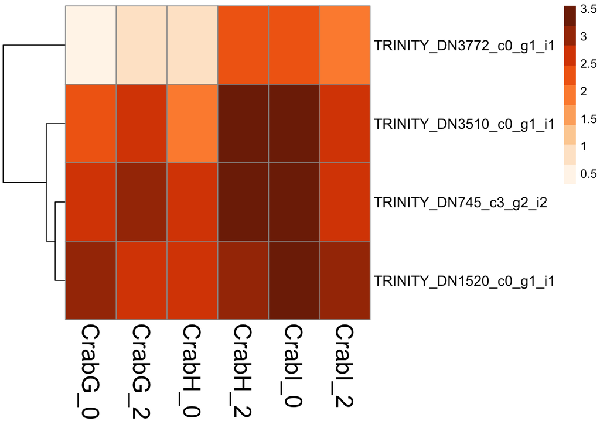

```r
pheatmap(GHI.heatmap.sub, cluster_row = TRUE, cluster_cols = FALSE, clustering_distance_rows = "euclidean", clustering_method = "average", show_rownames = TRUE, show_colnames = TRUE, treeheight_col = 80, legend = TRUE, color = heatmapOranges, fontsize_col = 20, fontsize_row = 12)
```

# Heatmap for crabs A, E, and G across 2 time points

Crab A - infected ambient Crab E - infected decreased Crab G - infected elevated

```r
AEG <- select(matrix_individ_log, Trinity_ID, CrabA_0, CrabA_2, CrabE_0, CrabE_2, CrabG_0, CrabG_2)
head(AEG)
```

```
##                 Trinity_ID   CrabA_0  CrabA_2  CrabE_0  CrabE_2  CrabG_0
## 1  TRINITY_DN5772_c0_g1_i1 0.0000000 0.602060 0.000000 0.000000 0.000000
## 2  TRINITY_DN2201_c0_g1_i1 0.0000000 0.000000 0.000000 0.000000 0.000000
## 3  TRINITY_DN4656_c0_g1_i1 1.5797836 1.556303 1.732394 1.568202 1.875061
## 4  TRINITY_DN7591_c0_g1_i1 0.6020600 1.414973 1.255273 0.602060 0.000000
## 5  TRINITY_DN6285_c0_g1_i4 0.0000000 0.000000 0.000000 0.000000 0.000000
## 6 TRINITY_DN28918_c0_g1_i1 0.4771213 0.000000 0.000000 0.000000 0.000000
##   CrabG_2
## 1       0
## 2       0
## 3       0
## 4       0
## 5       0
## 6       0
```

Set Trinity_ID as row names:

```r
rownames(AEG) <- AEG$Trinity_ID #set Trinity IDs as rownames
AEG.heatmap <- AEG[,-1] #remove redundant column
head(AEG.heatmap)
```

```
##                            CrabA_0  CrabA_2  CrabE_0  CrabE_2  CrabG_0 CrabG_2
## TRINITY_DN5772_c0_g1_i1  0.0000000 0.602060 0.000000 0.000000 0.000000       0
## TRINITY_DN2201_c0_g1_i1  0.0000000 0.000000 0.000000 0.000000 0.000000       0
## TRINITY_DN4656_c0_g1_i1  1.5797836 1.556303 1.732394 1.568202 1.875061       0
## TRINITY_DN7591_c0_g1_i1  0.6020600 1.414973 1.255273 0.602060 0.000000       0
## TRINITY_DN6285_c0_g1_i4  0.0000000 0.000000 0.000000 0.000000 0.000000       0
## TRINITY_DN28918_c0_g1_i1 0.4771213 0.000000 0.000000 0.000000 0.000000       0
```

Create heatmap colors:

```r
heatmapBlues <- RColorBrewer::brewer.pal(9, "Blues")
```

```r
include_list <- c("TRINITY_DN3510_c0_g1_i1", "TRINITY_DN745_c3_g2_i2", "TRINITY_DN1520_c0_g1_i1", "TRINITY_DN3772_c0_g1_i1")
AEG.heatmap.sub <- AEG.heatmap[include_list, ]
AEG.heatmap.sub
```

```
##                          CrabA_0  CrabA_2  CrabE_0  CrabE_2  CrabG_0   CrabG_2
## TRINITY_DN3510_c0_g1_i1 3.458184 3.250420 3.594503 3.156246 2.225309 2.6464037
## TRINITY_DN745_c3_g2_i2  2.999982 3.698138 3.342370 3.207700 2.699814 2.8302331
## TRINITY_DN1520_c0_g1_i1 3.462248 3.428459 3.371253 2.870989 2.952308 2.8055009
## TRINITY_DN3772_c0_g1_i1 1.518514 2.290035 2.478566 1.591065 0.301030 0.9542425
```

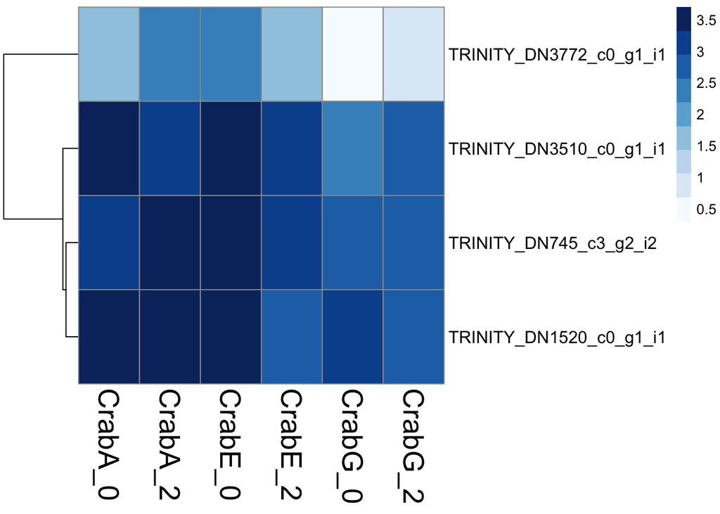

```r
pheatmap(AEG.heatmap.sub, cluster_row = TRUE, cluster_cols = FALSE, clustering_distance_rows = "euclidean", clustering_method = "average", show_rownames = TRUE, show_colnames = TRUE, treeheight_col = 80, legend = TRUE, color = heatmapBlues, fontsize_col = 20, fontsize_row = 12)
```

# Heat map for temeprature DEG list - with ABC and GHI

`join` temperature DEG list with individual crab count matrix

```r
temp_individual <- left_join(matrix_individ_log, temp_counts, by = "Trinity_ID")
head(temp_individual)
```

```
##                 Trinity_ID   CrabH_2  CrabE_2   CrabI_2 CrabC_17  CrabB_17
## 1  TRINITY_DN5772_c0_g1_i1 0.0000000 0.000000 0.0000000 0.000000 0.0000000
## 2  TRINITY_DN2201_c0_g1_i1 0.7781512 0.000000 0.8339754 0.000000 0.0000000
## 3  TRINITY_DN4656_c0_g1_i1 1.3010300 1.568202 0.6989700 1.113943 0.9542425
## 4  TRINITY_DN7591_c0_g1_i1 1.2304489 0.602060 0.4771213 0.301030 1.2041200
## 5  TRINITY_DN6285_c0_g1_i4 0.0000000 0.000000 0.0000000 0.698970 0.0000000
## 6 TRINITY_DN28918_c0_g1_i1 0.0000000 0.000000 0.0000000 0.000000 0.3010300
##    CrabG_0   CrabF_2  CrabE_0 CrabG_2 CrabC_0  CrabI_0 CrabD_0 CrabD_17
## 1 0.000000 0.0000000 0.000000       0 0.00000 0.000000       0        0
## 2 0.000000 0.7781512 0.000000       0 0.00000 0.000000       0        0
## 3 1.875061 0.9542425 1.732394       0 0.90309 1.278754       0        0
## 4 0.000000 1.0791812 1.255273       0 0.00000 1.623249       0        0
## 5 0.000000 0.0000000 0.000000       0 0.00000 0.000000       0        0
## 6 0.000000 0.0000000 0.000000       0 0.00000 0.301030       0        0
##     CrabB_0 CrabC_2 CrabB_2 CrabF_17   CrabA_0 CrabH_0 CrabA_17 CrabD_2
```

[output cut: 27 more lines]

Just want the ones that matched..

```r
tempdegs_individual <- filter(temp_individual, baseMean != "NA")
head(tempdegs_individual)
```

```
##                 Trinity_ID  CrabH_2  CrabE_2   CrabI_2  CrabC_17 CrabB_17
## 1 TRINITY_DN23918_c0_g1_i1 1.113943 0.301030 0.9030900 0.9542425 1.000000
## 2  TRINITY_DN2000_c0_g1_i1 2.957607 2.899873 2.3820170 2.6344773 2.879669
## 3   TRINITY_DN726_c0_g1_i3 2.663408 1.845786 2.2274059 2.3215280 2.299760
## 4 TRINITY_DN20407_c0_g1_i1 2.872156 2.824126 2.2576786 2.8920946 2.485721
## 5 TRINITY_DN23954_c2_g1_i1 2.561101 2.397940 2.1003705 2.6127839 2.301030
## 6  TRINITY_DN2313_c0_g2_i6 0.361350 1.094925 0.3769418 1.0545748 1.087036
##    CrabG_0   CrabF_2  CrabE_0  CrabG_2  CrabC_0  CrabI_0  CrabD_0 CrabD_17
## 1 0.000000 0.4771213 1.079181 0.000000 0.301030 1.000000 0.000000 0.000000
## 2 1.278754 2.6981005 3.376212 1.230449 2.110590 3.271842 0.000000 0.301030
## 3 1.903090 2.0461399 2.765638 1.591476 2.034356 2.509988 0.000000 0.000000
## 4 2.380211 2.5526682 3.061075 1.959041 3.038223 2.740363 2.460898 0.301030
## 5 2.654177 2.3541084 2.806180 2.232996 2.992111 2.593286 1.568202 1.612784
## 6 2.757387 2.2985736 2.386490 0.768194 1.878866 2.030782 1.222170 0.000000
##    CrabB_0   CrabC_2   CrabB_2 CrabF_17   CrabA_0  CrabH_0  CrabA_17  CrabD_2
```

[output cut: 27 more lines]

HEAT MAP FOR CRABS ABC AND GHI WITH TRINITY LIST FROM TEMPERATURE DEGS

```r
ABCGHI <- select(tempdegs_individual, Trinity_ID, CrabA_0, CrabA_2, CrabB_0, CrabB_2, CrabC_0, CrabC_2, CrabG_0, CrabG_2, CrabH_0, CrabH_2, CrabI_0, CrabI_2)
head(ABCGHI)
```

```
##                 Trinity_ID   CrabA_0   CrabA_2  CrabB_0   CrabB_2  CrabC_0
## 1 TRINITY_DN23918_c0_g1_i1 0.7781512 1.0791812 0.845098 0.0000000 0.301030
## 2  TRINITY_DN2000_c0_g1_i1 2.1789769 2.8512583 2.158362 0.0000000 2.110590
## 3   TRINITY_DN726_c0_g1_i3 2.2721109 2.4482068 1.594536 0.4771213 2.034356
## 4 TRINITY_DN20407_c0_g1_i1 3.0305997 3.2041200 2.904716 0.3010300 3.038223
## 5 TRINITY_DN23954_c2_g1_i1 2.8122447 3.1195858 3.210586 0.0000000 2.992111
## 6  TRINITY_DN2313_c0_g2_i6 2.5638274 0.6084191 2.066788 0.0000000 1.878866
##     CrabC_2  CrabG_0  CrabG_2  CrabH_0  CrabH_2  CrabI_0   CrabI_2
## 1 0.0000000 0.000000 0.000000 0.000000 1.113943 1.000000 0.9030900
## 2 1.6627578 1.278754 1.230449 1.505150 2.957607 3.271842 2.3820170
## 3 1.7481880 1.903090 1.591476 2.100371 2.663408 2.509988 2.2274059
## 4 2.8674675 2.380211 1.959041 2.703291 2.872156 2.740363 2.2576786
## 5 2.8543060 2.654177 2.232996 3.090611 2.561101 2.593286 2.1003705
## 6 0.7530466 2.757387 0.768194 2.464902 0.361350 2.030782 0.3769418
```

Create heatmap colors:

```r
heatmapReds <- RColorBrewer::brewer.pal(9, "Reds")
```

Set Trinity_ID as row names:

```r
rownames(ABCGHI) <- ABCGHI$Trinity_ID #set Trinity IDs as rownames
ABCGHI.heatmap <- ABCGHI[,-1] #remove redundant column
head(ABCGHI.heatmap)
```

```
##                            CrabA_0   CrabA_2  CrabB_0   CrabB_2  CrabC_0
## TRINITY_DN23918_c0_g1_i1 0.7781512 1.0791812 0.845098 0.0000000 0.301030
## TRINITY_DN2000_c0_g1_i1  2.1789769 2.8512583 2.158362 0.0000000 2.110590
## TRINITY_DN726_c0_g1_i3   2.2721109 2.4482068 1.594536 0.4771213 2.034356
## TRINITY_DN20407_c0_g1_i1 3.0305997 3.2041200 2.904716 0.3010300 3.038223
## TRINITY_DN23954_c2_g1_i1 2.8122447 3.1195858 3.210586 0.0000000 2.992111
## TRINITY_DN2313_c0_g2_i6  2.5638274 0.6084191 2.066788 0.0000000 1.878866
##                            CrabC_2  CrabG_0  CrabG_2  CrabH_0  CrabH_2  CrabI_0
## TRINITY_DN23918_c0_g1_i1 0.0000000 0.000000 0.000000 0.000000 1.113943 1.000000
## TRINITY_DN2000_c0_g1_i1  1.6627578 1.278754 1.230449 1.505150 2.957607 3.271842
## TRINITY_DN726_c0_g1_i3   1.7481880 1.903090 1.591476 2.100371 2.663408 2.509988
## TRINITY_DN20407_c0_g1_i1 2.8674675 2.380211 1.959041 2.703291 2.872156 2.740363
## TRINITY_DN23954_c2_g1_i1 2.8543060 2.654177 2.232996 3.090611 2.561101 2.593286
## TRINITY_DN2313_c0_g2_i6  0.7530466 2.757387 0.768194 2.464902 0.361350 2.030782
##                            CrabI_2
## TRINITY_DN23918_c0_g1_i1 0.9030900
## TRINITY_DN2000_c0_g1_i1  2.3820170
## TRINITY_DN726_c0_g1_i3   2.2274059
## TRINITY_DN20407_c0_g1_i1 2.2576786
## TRINITY_DN23954_c2_g1_i1 2.1003705
## TRINITY_DN2313_c0_g2_i6  0.3769418
```

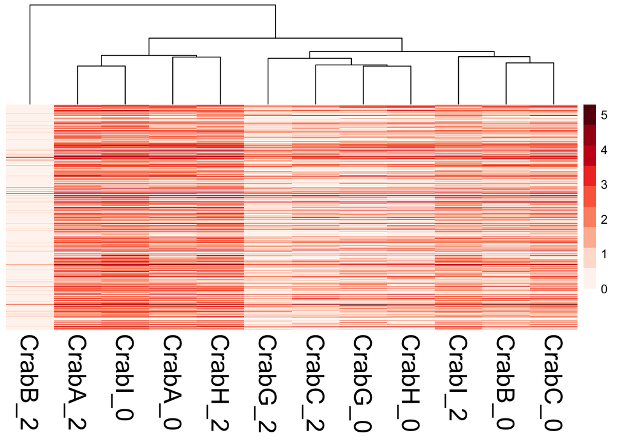

```r
pheatmap(ABCGHI.heatmap, cluster_row = FALSE, cluster_cols = TRUE, clustering_distance_rows = "euclidean", clustering_method = "average", show_rownames = FALSE, show_colnames = TRUE, treeheight_col = 80, legend = TRUE, color = heatmapReds, fontsize_col = 20, fontsize_row = 12)
```

DEG temperature list that matched with the individual crab gene counts

# Heat maps with infection comparison DEG list and individual crabs

`join` infect_counts with matrix_individ_log

```r
infdegs_individual <- left_join(matrix_individ_log, infect_counts, by = "Trinity_ID")
head(infdegs_individual)
```

```
##                 Trinity_ID   CrabH_2  CrabE_2   CrabI_2 CrabC_17  CrabB_17
## 1  TRINITY_DN5772_c0_g1_i1 0.0000000 0.000000 0.0000000 0.000000 0.0000000
## 2  TRINITY_DN2201_c0_g1_i1 0.7781512 0.000000 0.8339754 0.000000 0.0000000
## 3  TRINITY_DN4656_c0_g1_i1 1.3010300 1.568202 0.6989700 1.113943 0.9542425
## 4  TRINITY_DN7591_c0_g1_i1 1.2304489 0.602060 0.4771213 0.301030 1.2041200
## 5  TRINITY_DN6285_c0_g1_i4 0.0000000 0.000000 0.0000000 0.698970 0.0000000
## 6 TRINITY_DN28918_c0_g1_i1 0.0000000 0.000000 0.0000000 0.000000 0.3010300
##    CrabG_0   CrabF_2  CrabE_0 CrabG_2 CrabC_0  CrabI_0 CrabD_0 CrabD_17
## 1 0.000000 0.0000000 0.000000       0 0.00000 0.000000       0        0
## 2 0.000000 0.7781512 0.000000       0 0.00000 0.000000       0        0
## 3 1.875061 0.9542425 1.732394       0 0.90309 1.278754       0        0
## 4 0.000000 1.0791812 1.255273       0 0.00000 1.623249       0        0
## 5 0.000000 0.0000000 0.000000       0 0.00000 0.000000       0        0
## 6 0.000000 0.0000000 0.000000       0 0.00000 0.301030       0        0
##     CrabB_0 CrabC_2 CrabB_2 CrabF_17   CrabA_0 CrabH_0 CrabA_17 CrabD_2
```

[output cut: 20 more lines]

Just want the ones that matched..

```r
infected_individual_degs <- filter(infdegs_individual, baseMean != "NA")
head(infected_individual_degs)
```

```
##                 Trinity_ID CrabH_2 CrabE_2 CrabI_2 CrabC_17 CrabB_17 CrabG_0
## 1 TRINITY_DN13534_c0_g1_i1       0       0       0 0.000000        0       0
## 2  TRINITY_DN5315_c0_g1_i1       0       0       0 0.845098        0       0
## 3  TRINITY_DN9677_c0_g1_i1       0       0       0 0.000000        0       0
## 4  TRINITY_DN4409_c0_g1_i1       0       0       0 0.000000        0       0
## 5  TRINITY_DN7412_c0_g2_i1       0       0       0 0.000000        0       0
## 6 TRINITY_DN22660_c0_g1_i1       0       0       0 0.602060        0       0
##   CrabF_2 CrabE_0 CrabG_2 CrabC_0 CrabI_0 CrabD_0 CrabD_17 CrabB_0 CrabC_2
## 1       0       0       0       0       0       0        0 0.00000       0
## 2       0       0       0       0       0       0        0 0.00000       0
## 3       0       0       0       0       0       0        0 0.00000       0
## 4       0       0       0       0       0       0        0 0.00000       0
## 5       0       0       0       0       0       0        0 0.30103       0
## 6       0       0       0       0       0       0        0 0.00000       0
##   CrabB_2 CrabF_17 CrabA_0 CrabH_0 CrabA_17 CrabD_2 CrabE_17 CrabA_2 CrabF_0
```

[output cut: 20 more lines]

```r
ABCGHI_infected <- select(infected_individual_degs, Trinity_ID, CrabA_0, CrabA_2, CrabB_0, CrabB_2, CrabC_0, CrabC_2, CrabG_0, CrabG_2, CrabH_0, CrabH_2, CrabI_0, CrabI_2)
head(ABCGHI_infected)
```

```
##                 Trinity_ID CrabA_0 CrabA_2 CrabB_0 CrabB_2 CrabC_0 CrabC_2
## 1 TRINITY_DN13534_c0_g1_i1       0 0.00000 0.00000       0       0       0
## 2  TRINITY_DN5315_c0_g1_i1       0 0.00000 0.00000       0       0       0
## 3  TRINITY_DN9677_c0_g1_i1       0 0.00000 0.00000       0       0       0
## 4  TRINITY_DN4409_c0_g1_i1       0 0.00000 0.00000       0       0       0
## 5  TRINITY_DN7412_c0_g2_i1       0 0.30103 0.30103       0       0       0
## 6 TRINITY_DN22660_c0_g1_i1       0 0.00000 0.00000       0       0       0
##   CrabG_0 CrabG_2 CrabH_0 CrabH_2 CrabI_0 CrabI_2
## 1       0       0       0       0       0       0
## 2       0       0       0       0       0       0
## 3       0       0       0       0       0       0
## 4       0       0       0       0       0       0
## 5       0       0       0       0       0       0
## 6       0       0       0       0       0       0
```

Set Trinity_ID as row names:

```r
rownames(ABCGHI_infected) <- ABCGHI_infected$Trinity_ID #set Trinity IDs as rownames
ABCGHIinfected.heatmap <- ABCGHI_infected[,-1] #remove redundant column
head(ABCGHIinfected.heatmap)
```

```
##                          CrabA_0 CrabA_2 CrabB_0 CrabB_2 CrabC_0 CrabC_2
## TRINITY_DN13534_c0_g1_i1       0 0.00000 0.00000       0       0       0
## TRINITY_DN5315_c0_g1_i1        0 0.00000 0.00000       0       0       0
## TRINITY_DN9677_c0_g1_i1        0 0.00000 0.00000       0       0       0
## TRINITY_DN4409_c0_g1_i1        0 0.00000 0.00000       0       0       0
## TRINITY_DN7412_c0_g2_i1        0 0.30103 0.30103       0       0       0
## TRINITY_DN22660_c0_g1_i1       0 0.00000 0.00000       0       0       0
##                          CrabG_0 CrabG_2 CrabH_0 CrabH_2 CrabI_0 CrabI_2
## TRINITY_DN13534_c0_g1_i1       0       0       0       0       0       0
## TRINITY_DN5315_c0_g1_i1        0       0       0       0       0       0
## TRINITY_DN9677_c0_g1_i1        0       0       0       0       0       0
## TRINITY_DN4409_c0_g1_i1        0       0       0       0       0       0
## TRINITY_DN7412_c0_g2_i1        0       0       0       0       0       0
## TRINITY_DN22660_c0_g1_i1       0       0       0       0       0       0
```

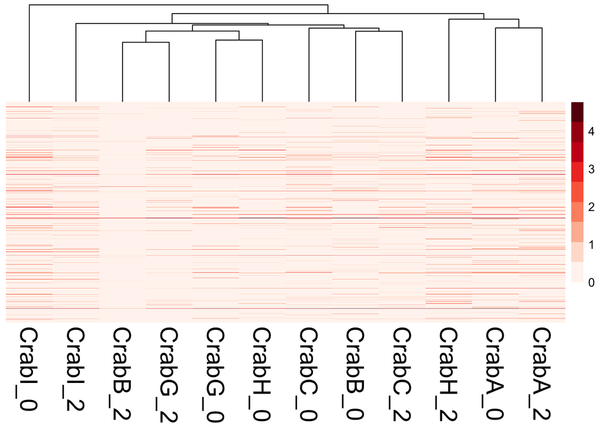

```r
pheatmap(ABCGHIinfected.heatmap, cluster_row = FALSE, cluster_cols = TRUE, clustering_distance_rows = "euclidean", clustering_method = "average", show_rownames = FALSE, show_colnames = TRUE, treeheight_col = 80, legend = TRUE, color = heatmapReds, fontsize_col = 20, fontsize_row = 12)
```

# Heat map of infected DEGs with crabs D and E across time points

D –> uinfected decreased E –> infected decreased

```r
DE_infected <- select(infected_individual_degs, Trinity_ID, CrabD_0, CrabD_2, CrabD_17, CrabE_0, CrabE_2, CrabE_17)
head(DE_infected)
```

```
##                 Trinity_ID CrabD_0 CrabD_2 CrabD_17 CrabE_0 CrabE_2 CrabE_17
## 1 TRINITY_DN13534_c0_g1_i1       0       0        0       0       0        0
## 2  TRINITY_DN5315_c0_g1_i1       0       0        0       0       0        0
## 3  TRINITY_DN9677_c0_g1_i1       0       0        0       0       0        0
## 4  TRINITY_DN4409_c0_g1_i1       0       0        0       0       0        0
## 5  TRINITY_DN7412_c0_g2_i1       0       0        0       0       0        0
## 6 TRINITY_DN22660_c0_g1_i1       0       0        0       0       0        0
```

Set Trinity_ID as row names:

```r
rownames(DE_infected) <- DE_infected$Trinity_ID #set Trinity IDs as rownames
DEinfected.heatmap <- DE_infected[,-1] #remove redundant column
head(DEinfected.heatmap)
```

```
##                          CrabD_0 CrabD_2 CrabD_17 CrabE_0 CrabE_2 CrabE_17
## TRINITY_DN13534_c0_g1_i1       0       0        0       0       0        0
## TRINITY_DN5315_c0_g1_i1        0       0        0       0       0        0
## TRINITY_DN9677_c0_g1_i1        0       0        0       0       0        0
## TRINITY_DN4409_c0_g1_i1        0       0        0       0       0        0
## TRINITY_DN7412_c0_g2_i1        0       0        0       0       0        0
## TRINITY_DN22660_c0_g1_i1       0       0        0       0       0        0
```

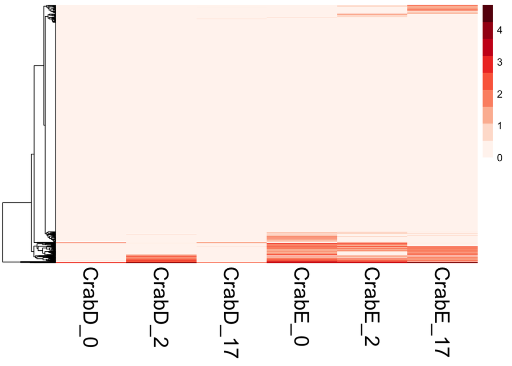

```r
pheatmap(DEinfected.heatmap, cluster_row = TRUE, cluster_cols = FALSE, clustering_distance_rows = "euclidean", clustering_method = "average", show_rownames = FALSE, show_colnames = TRUE, treeheight_col = 80, legend = TRUE, color = heatmapReds, fontsize_col = 20, fontsize_row = 12)
```

Crab D –> uninfected decreased Crab E –> infected decreased

# Heat map of all individual crabs gene counts –> ones that matched with those in the transcriptome v. 1.5 stress response list

```r
ALLcrabs <- select(matrix_individ_log, Trinity_ID, CrabA_0, CrabA_2, CrabA_17, CrabB_0, CrabB_2, CrabB_17, CrabC_0, CrabC_2, CrabC_17, CrabD_0, CrabD_2, CrabD_17, CrabE_0, CrabE_2, CrabE_17, CrabF_0, CrabF_2, CrabF_17, CrabG_0, CrabG_2, CrabH_0, CrabH_2, CrabI_0, CrabI_2)
head(ALLcrabs)
```

```
##                 Trinity_ID   CrabA_0  CrabA_2 CrabA_17   CrabB_0 CrabB_2
## 1  TRINITY_DN5772_c0_g1_i1 0.0000000 0.602060        0 0.0000000       0
## 2  TRINITY_DN2201_c0_g1_i1 0.0000000 0.000000        0 0.0000000       0
## 3  TRINITY_DN4656_c0_g1_i1 1.5797836 1.556303        0 0.6989700       0
## 4  TRINITY_DN7591_c0_g1_i1 0.6020600 1.414973        0 0.4771213       0
## 5  TRINITY_DN6285_c0_g1_i4 0.0000000 0.000000        0 0.0000000       0
## 6 TRINITY_DN28918_c0_g1_i1 0.4771213 0.000000        0 0.0000000       0
##    CrabB_17 CrabC_0 CrabC_2 CrabC_17 CrabD_0 CrabD_2 CrabD_17  CrabE_0  CrabE_2
## 1 0.0000000 0.00000 0.00000 0.000000       0       0        0 0.000000 0.000000
## 2 0.0000000 0.00000 0.00000 0.000000       0       0        0 0.000000 0.000000
## 3 0.9542425 0.90309 0.60206 1.113943       0       0        0 1.732394 1.568202
## 4 1.2041200 0.00000 0.00000 0.301030       0       0        0 1.255273 0.602060
## 5 0.0000000 0.00000 0.00000 0.698970       0       0        0 0.000000 0.000000
## 6 0.3010300 0.00000 0.00000 0.000000       0       0        0 0.000000 0.000000
##    CrabE_17  CrabF_0   CrabF_2 CrabF_17  CrabG_0 CrabG_2 CrabH_0   CrabH_2
## 1 0.0000000 0.000000 0.0000000        0 0.000000       0 0.00000 0.0000000
## 2 1.9084850 1.469071 0.7781512        0 0.000000       0 0.00000 0.7781512
## 3 1.3222193 1.176091 0.9542425        0 1.875061       0 0.90309 1.3010300
## 4 1.5910646 1.568202 1.0791812        0 0.000000       0 0.00000 1.2304489
## 5 0.8417348 0.000000 0.0000000        0 0.000000       0 0.00000 0.0000000
## 6 0.0000000 0.000000 0.0000000        0 0.000000       0 0.00000 0.0000000
##    CrabI_0   CrabI_2
## 1 0.000000 0.0000000
## 2 0.000000 0.8339754
## 3 1.278754 0.6989700
## 4 1.623249 0.4771213
## 5 0.000000 0.0000000
## 6 0.301030 0.0000000
```

Read in the stress response gene list from transcriptome v. 1.5:

```r
stress <- read.delim("../../project-crab/analyses/crab_stress-response-genes.tab", sep = '\t')
head(stress)
```

```
##                 Trinity_ID      GO_ID          GOslim biological_process V2
## 1  TRINITY_DN9987_c0_g1_i1 GO:0000012 stress response                  P sp
## 2  TRINITY_DN1502_c0_g2_i1 GO:0000012 stress response                  P sp
## 3 TRINITY_DN12632_c0_g1_i2 GO:0000012 stress response                  P sp
## 4  TRINITY_DN3327_c0_g1_i1 GO:0000012 stress response                  P sp
## 5 TRINITY_DN14935_c0_g1_i1 GO:0000012 stress response                  P sp
## 6   TRINITY_DN841_c1_g1_i1 GO:0000012 stress response                  P sp
##   uniprot_acc_ID          V4   V5  V6  V7 V8.x V9.x V10.x V11.x V12      V13
## 1         O54935 XRCC1_CRIGR 51.5  97  45    2  238   525   320 415  2.4e-22
## 2         P18887 XRCC1_HUMAN 45.5 231 114    7  772   113     1 230  1.5e-41
## 3         P49917 DNLI4_HUMAN 46.2 604 317    5 1826    27    15 614 5.1e-161
## 4         Q54CR9 DNLI4_DICDI 32.6 129  86    1  479    96   821 949  5.6e-14
## 5         Q6ZNB5 TRC2L_HUMAN 42.3 104  57    1   98   400     9 112  1.7e-18
## 6         Q923E4  SIR1_MOUSE 47.7 554 179    9 1943   462   164 666 4.7e-130
##     V14  entry_name review_status
```

[output cut: 55 more lines]

`join` the stress response gene list with the Trinity IDs from all individual crabs:

```r
stress_ALLcrabs <- left_join(ALLcrabs, stress, by = "Trinity_ID")
head(stress_ALLcrabs)
```

```
##                 Trinity_ID   CrabA_0  CrabA_2 CrabA_17   CrabB_0 CrabB_2
## 1  TRINITY_DN5772_c0_g1_i1 0.0000000 0.602060        0 0.0000000       0
## 2  TRINITY_DN2201_c0_g1_i1 0.0000000 0.000000        0 0.0000000       0
## 3  TRINITY_DN4656_c0_g1_i1 1.5797836 1.556303        0 0.6989700       0
## 4  TRINITY_DN7591_c0_g1_i1 0.6020600 1.414973        0 0.4771213       0
## 5  TRINITY_DN6285_c0_g1_i4 0.0000000 0.000000        0 0.0000000       0
## 6 TRINITY_DN28918_c0_g1_i1 0.4771213 0.000000        0 0.0000000       0
##    CrabB_17 CrabC_0 CrabC_2 CrabC_17 CrabD_0 CrabD_2 CrabD_17  CrabE_0  CrabE_2
## 1 0.0000000 0.00000 0.00000 0.000000       0       0        0 0.000000 0.000000
## 2 0.0000000 0.00000 0.00000 0.000000       0       0        0 0.000000 0.000000
## 3 0.9542425 0.90309 0.60206 1.113943       0       0        0 1.732394 1.568202
## 4 1.2041200 0.00000 0.00000 0.301030       0       0        0 1.255273 0.602060
## 5 0.0000000 0.00000 0.00000 0.698970       0       0        0 0.000000 0.000000
## 6 0.3010300 0.00000 0.00000 0.000000       0       0        0 0.000000 0.000000
##    CrabE_17  CrabF_0   CrabF_2 CrabF_17  CrabG_0 CrabG_2 CrabH_0   CrabH_2
```

[output cut: 34 more lines]

Subset just the ones that matched:

```r
matched_stress_ALLcrabs <- filter(stress_ALLcrabs, GO_ID != "NA")
head(matched_stress_ALLcrabs)
```

```
##                 Trinity_ID  CrabA_0  CrabA_2 CrabA_17   CrabB_0   CrabB_2
## 1  TRINITY_DN3854_c0_g1_i1 0.000000 0.000000        0 0.0000000 0.0000000
## 2  TRINITY_DN3854_c0_g1_i1 0.000000 0.000000        0 0.0000000 0.0000000
## 3 TRINITY_DN10774_c0_g1_i3 1.400279 1.764677        0 1.4578062 0.0000000
## 4   TRINITY_DN566_c0_g1_i3 1.850070 1.216087        0 0.7781512 0.6020600
## 5  TRINITY_DN1413_c0_g1_i4 0.000000 0.000000        0 0.0000000 0.0000000
## 6 TRINITY_DN14188_c0_g3_i1 1.637209 1.744254        0 1.3627840 0.4771213
##    CrabB_17  CrabC_0  CrabC_2 CrabC_17 CrabD_0  CrabD_2 CrabD_17  CrabE_0
## 1 0.0000000 0.000000 0.000000 0.000000       0 0.000000        0 0.301030
## 2 0.0000000 0.000000 0.000000 0.000000       0 0.000000        0 0.301030
## 3 1.8957760 1.071772 0.988336 1.816632       0 2.127105        0 2.208337
## 4 0.0000000 0.000000 0.602060 1.755875       0 0.000000        0 2.294466
## 5 0.0000000 0.000000 0.000000 0.000000       0 0.000000        0 0.000000
## 6 0.9332848 1.725258 1.591065 1.111901       0 0.000000        0 1.328685
##    CrabE_2 CrabE_17  CrabF_0   CrabF_2 CrabF_17  CrabG_0 CrabG_2   CrabH_0
```

[output cut: 76 more lines]

Subset just the rows that Trinity IDs and the individual crabs:

```r
stressALLcrabs <- select(matched_stress_ALLcrabs, Trinity_ID, CrabA_0, CrabA_2, CrabA_17, CrabB_0, CrabB_2, CrabB_17, CrabC_0, CrabC_2, CrabC_17, CrabD_0, CrabD_2, CrabD_17, CrabE_0, CrabE_2, CrabE_17, CrabF_0, CrabF_2, CrabF_17, CrabG_0, CrabG_2, CrabH_0, CrabH_2, CrabI_0, CrabI_2)
head(stressALLcrabs)
```

```
##                 Trinity_ID  CrabA_0  CrabA_2 CrabA_17   CrabB_0   CrabB_2
## 1  TRINITY_DN3854_c0_g1_i1 0.000000 0.000000        0 0.0000000 0.0000000
## 2  TRINITY_DN3854_c0_g1_i1 0.000000 0.000000        0 0.0000000 0.0000000
## 3 TRINITY_DN10774_c0_g1_i3 1.400279 1.764677        0 1.4578062 0.0000000
## 4   TRINITY_DN566_c0_g1_i3 1.850070 1.216087        0 0.7781512 0.6020600
## 5  TRINITY_DN1413_c0_g1_i4 0.000000 0.000000        0 0.0000000 0.0000000
## 6 TRINITY_DN14188_c0_g3_i1 1.637209 1.744254        0 1.3627840 0.4771213
##    CrabB_17  CrabC_0  CrabC_2 CrabC_17 CrabD_0  CrabD_2 CrabD_17  CrabE_0
## 1 0.0000000 0.000000 0.000000 0.000000       0 0.000000        0 0.301030
## 2 0.0000000 0.000000 0.000000 0.000000       0 0.000000        0 0.301030
## 3 1.8957760 1.071772 0.988336 1.816632       0 2.127105        0 2.208337
## 4 0.0000000 0.000000 0.602060 1.755875       0 0.000000        0 2.294466
## 5 0.0000000 0.000000 0.000000 0.000000       0 0.000000        0 0.000000
## 6 0.9332848 1.725258 1.591065 1.111901       0 0.000000        0 1.328685
##    CrabE_2 CrabE_17  CrabF_0   CrabF_2 CrabF_17  CrabG_0 CrabG_2   CrabH_0
## 1 0.000000 0.000000 0.301030 0.4771213  0.00000 0.000000 0.00000 0.0000000
## 2 0.000000 0.000000 0.301030 0.4771213  0.00000 0.000000 0.00000 0.0000000
## 3 1.791073 2.208113 2.029696 1.6766570  0.00000 1.706376 0.00000 0.9161907
## 4 1.518514 0.000000 0.000000 1.2041200  0.30103 0.698970 0.00000 0.4771213
## 5 0.000000 0.000000 0.000000 0.0000000  0.00000 0.000000 0.00000 0.0000000
## 6 1.230577 1.421637 1.181272 0.8882918  0.00000 1.992333 0.60206 1.5440680
##    CrabH_2  CrabI_0  CrabI_2
## 1 0.000000 0.000000 0.000000
## 2 0.000000 0.000000 0.000000
## 3 2.098197 1.966334 1.252683
## 4 1.728045 0.000000 1.176091
## 5 0.000000 0.000000 0.000000
## 6 0.000000 0.000000 0.000000
```

```r
stressALLcrabs_distinct <- distinct(stressALLcrabs)
head(stressALLcrabs_distinct)
```

```
##                 Trinity_ID  CrabA_0  CrabA_2 CrabA_17   CrabB_0   CrabB_2
## 1  TRINITY_DN3854_c0_g1_i1 0.000000 0.000000        0 0.0000000 0.0000000
## 2 TRINITY_DN10774_c0_g1_i3 1.400279 1.764677        0 1.4578062 0.0000000
## 3   TRINITY_DN566_c0_g1_i3 1.850070 1.216087        0 0.7781512 0.6020600
## 4  TRINITY_DN1413_c0_g1_i4 0.000000 0.000000        0 0.0000000 0.0000000
## 5 TRINITY_DN14188_c0_g3_i1 1.637209 1.744254        0 1.3627840 0.4771213
## 6 TRINITY_DN21587_c0_g1_i1 1.230449 1.322219        0 0.6020600 0.0000000
##    CrabB_17  CrabC_0  CrabC_2 CrabC_17 CrabD_0  CrabD_2 CrabD_17  CrabE_0
## 1 0.0000000 0.000000 0.000000 0.000000       0 0.000000 0.000000 0.301030
## 2 1.8957760 1.071772 0.988336 1.816632       0 2.127105 0.000000 2.208337
## 3 0.0000000 0.000000 0.602060 1.755875       0 0.000000 0.000000 2.294466
## 4 0.0000000 0.000000 0.000000 0.000000       0 0.000000 0.000000 0.000000
## 5 0.9332848 1.725258 1.591065 1.111901       0 0.000000 0.000000 1.328685
## 6 0.3010300 0.698970 0.301030 0.000000       0 0.000000 1.146128 0.903090
##    CrabE_2 CrabE_17  CrabF_0   CrabF_2 CrabF_17  CrabG_0 CrabG_2   CrabH_0
## 1 0.000000 0.000000 0.301030 0.4771213  0.00000 0.000000 0.00000 0.0000000
## 2 1.791073 2.208113 2.029696 1.6766570  0.00000 1.706376 0.00000 0.9161907
## 3 1.518514 0.000000 0.000000 1.2041200  0.30103 0.698970 0.00000 0.4771213
## 4 0.000000 0.000000 0.000000 0.0000000  0.00000 0.000000 0.00000 0.0000000
## 5 1.230577 1.421637 1.181272 0.8882918  0.00000 1.992333 0.60206 1.5440680
## 6 0.000000 1.447158 1.662758 0.4771213  0.00000 0.000000 0.00000 0.4771213
##    CrabH_2  CrabI_0   CrabI_2
## 1 0.000000 0.000000 0.0000000
## 2 2.098197 1.966334 1.2526832
## 3 1.728045 0.000000 1.1760913
## 4 0.000000 0.000000 0.0000000
## 5 0.000000 0.000000 0.0000000
## 6 0.000000 1.568202 0.4771213
```

Set Trinity_ID as row names:

```r
rownames(stressALLcrabs_distinct) <- stressALLcrabs_distinct$Trinity_ID #set Trinity IDs as rownames
stressALLcrabs_distinct.heatmap <- stressALLcrabs_distinct[,-1] #remove redundant column
head(stressALLcrabs_distinct.heatmap)
```

```
##                           CrabA_0  CrabA_2 CrabA_17   CrabB_0   CrabB_2
## TRINITY_DN3854_c0_g1_i1  0.000000 0.000000        0 0.0000000 0.0000000
## TRINITY_DN10774_c0_g1_i3 1.400279 1.764677        0 1.4578062 0.0000000
## TRINITY_DN566_c0_g1_i3   1.850070 1.216087        0 0.7781512 0.6020600
## TRINITY_DN1413_c0_g1_i4  0.000000 0.000000        0 0.0000000 0.0000000
## TRINITY_DN14188_c0_g3_i1 1.637209 1.744254        0 1.3627840 0.4771213
## TRINITY_DN21587_c0_g1_i1 1.230449 1.322219        0 0.6020600 0.0000000
##                           CrabB_17  CrabC_0  CrabC_2 CrabC_17 CrabD_0  CrabD_2
## TRINITY_DN3854_c0_g1_i1  0.0000000 0.000000 0.000000 0.000000       0 0.000000
## TRINITY_DN10774_c0_g1_i3 1.8957760 1.071772 0.988336 1.816632       0 2.127105
## TRINITY_DN566_c0_g1_i3   0.0000000 0.000000 0.602060 1.755875       0 0.000000
## TRINITY_DN1413_c0_g1_i4  0.0000000 0.000000 0.000000 0.000000       0 0.000000
## TRINITY_DN14188_c0_g3_i1 0.9332848 1.725258 1.591065 1.111901       0 0.000000
## TRINITY_DN21587_c0_g1_i1 0.3010300 0.698970 0.301030 0.000000       0 0.000000
##                          CrabD_17  CrabE_0  CrabE_2 CrabE_17  CrabF_0   CrabF_2
## TRINITY_DN3854_c0_g1_i1  0.000000 0.301030 0.000000 0.000000 0.301030 0.4771213
## TRINITY_DN10774_c0_g1_i3 0.000000 2.208337 1.791073 2.208113 2.029696 1.6766570
## TRINITY_DN566_c0_g1_i3   0.000000 2.294466 1.518514 0.000000 0.000000 1.2041200
## TRINITY_DN1413_c0_g1_i4  0.000000 0.000000 0.000000 0.000000 0.000000 0.0000000
## TRINITY_DN14188_c0_g3_i1 0.000000 1.328685 1.230577 1.421637 1.181272 0.8882918
## TRINITY_DN21587_c0_g1_i1 1.146128 0.903090 0.000000 1.447158 1.662758 0.4771213
##                          CrabF_17  CrabG_0 CrabG_2   CrabH_0  CrabH_2  CrabI_0
## TRINITY_DN3854_c0_g1_i1   0.00000 0.000000 0.00000 0.0000000 0.000000 0.000000
## TRINITY_DN10774_c0_g1_i3  0.00000 1.706376 0.00000 0.9161907 2.098197 1.966334
## TRINITY_DN566_c0_g1_i3    0.30103 0.698970 0.00000 0.4771213 1.728045 0.000000
## TRINITY_DN1413_c0_g1_i4   0.00000 0.000000 0.00000 0.0000000 0.000000 0.000000
## TRINITY_DN14188_c0_g3_i1  0.00000 1.992333 0.60206 1.5440680 0.000000 0.000000
## TRINITY_DN21587_c0_g1_i1  0.00000 0.000000 0.00000 0.4771213 0.000000 1.568202
##                            CrabI_2
## TRINITY_DN3854_c0_g1_i1  0.0000000
## TRINITY_DN10774_c0_g1_i3 1.2526832
## TRINITY_DN566_c0_g1_i3   1.1760913
## TRINITY_DN1413_c0_g1_i4  0.0000000
## TRINITY_DN14188_c0_g3_i1 0.0000000
## TRINITY_DN21587_c0_g1_i1 0.4771213
```

3033 rows

Cluster by columns (samples)

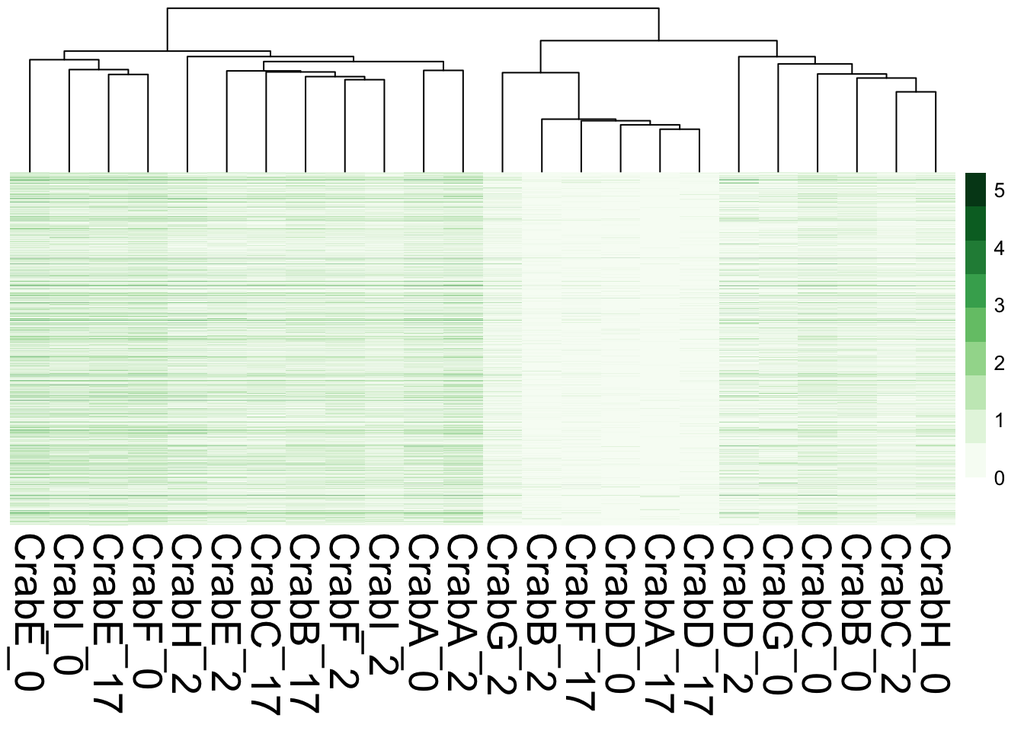

```r
pheatmap(stressALLcrabs_distinct.heatmap, cluster_row = FALSE, cluster_cols = TRUE, clustering_distance_rows = "euclidean", clustering_method = "average", show_rownames = FALSE, show_colnames = TRUE, treeheight_col = 80, legend = TRUE, color = heatmapGreens, fontsize_col = 20, fontsize_row = 12)
```

Cluster by rows (Trinity IDs)

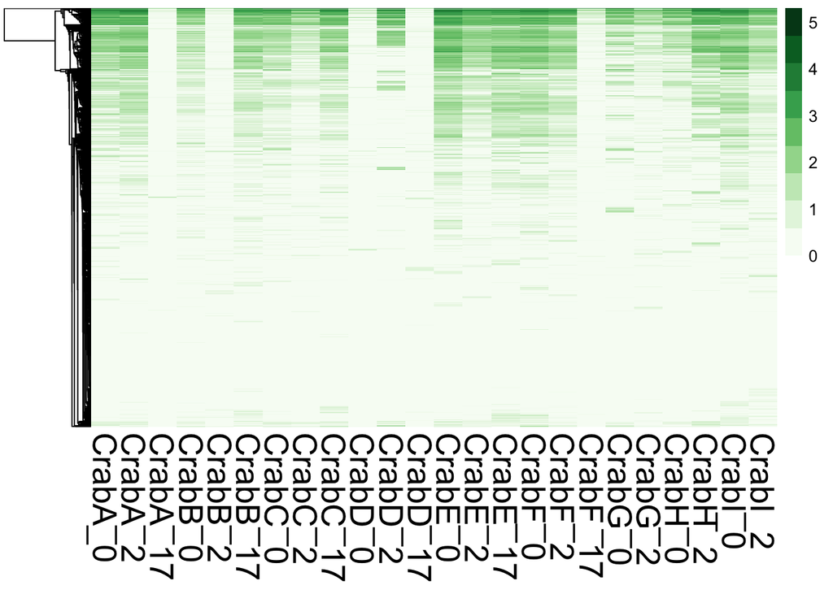

```r
pheatmap(stressALLcrabs_distinct.heatmap, cluster_row = TRUE, cluster_cols = FALSE, clustering_distance_rows = "euclidean", clustering_method = "average", show_rownames = FALSE, show_colnames = TRUE, treeheight_col = 80, legend = TRUE, color = heatmapGreens, fontsize_col = 20, fontsize_row = 12)
```

# Create a heatmap using normalized counts comparing ABC and GHI (day 2) using the ABC GHI DEG list

Read in normalized count matrix:

```r
norm_cts <- read.delim("../data/salmon.isoform.TMM.EXPR.matrix")
head(norm_cts)
```

```
##                          X X294_quant X254_quant X280_quant X485_quant
## 1  TRINITY_DN5772_c0_g1_i1      0.000      0.000      0.000      0.000
## 2  TRINITY_DN2201_c0_g1_i1      0.406      0.000      1.537      0.000
## 3  TRINITY_DN4656_c0_g1_i1      2.445      7.675      1.673      3.277
## 4  TRINITY_DN7591_c0_g1_i1      3.369      1.049      1.366      0.444
## 5  TRINITY_DN6285_c0_g1_i4      0.000      0.000      0.000      1.806
## 6 TRINITY_DN28918_c0_g1_i1      0.000      0.000      0.000      0.000
##   X481_quant X173_quant X222_quant X151_quant X272_quant X132_quant X127_quant
## 1      0.000      0.000      0.000      0.000          0       0.00      0.000
## 2      0.000      0.000      0.817      0.000          0       0.00      0.000
## 3      2.057     28.523      2.074      4.561          0       2.39      2.925
## 4      6.289      0.000      4.666      2.383          0       0.00     10.800
## 5      0.000      0.000      0.000      0.000          0       0.00      0.000
## 6      1.520      0.000      0.000      0.000          0       0.00      0.919
##   X73_quant X427_quant X118_quant X334_quant X349_quant X425_quant X178_quant
## 1         0          0      0.000      0.000          0          0      0.000
## 2         0          0      0.000      0.000          0          0      0.000
## 3         0          0      2.047      1.627          0          0      6.384
## 4         0          0      1.650      0.000          0          0      0.839
## 5         0          0      0.000      0.000          0          0      0.000
## 6         0          0      0.000      0.000          0          0      1.990
##   X72_quant X463_quant X221_quant X445_quant X359_quant X113_quant
## 1     0.000          0          0      0.000      1.976      0.000
## 2     0.000          0          0      7.232      0.000      2.599
## 3     2.853          0          0      2.853      4.987      2.019
## 4     0.000          0          0      8.787      5.773      8.427
## 5     0.000          0          0      1.397      0.000      0.000
## 6     0.000          0          0      0.000      0.000      0.000
```

Subset rows to do with crabs ABC and GHI (just Day 2):

```r
abcghi_nmcts <- select(norm_cts, X, X359_quant, X349_quant, X334_quant, X272_quant, X294_quant, X280_quant)
head(abcghi_nmcts)
```

```
##                          X X359_quant X349_quant X334_quant X272_quant
## 1  TRINITY_DN5772_c0_g1_i1      1.976          0      0.000          0
## 2  TRINITY_DN2201_c0_g1_i1      0.000          0      0.000          0
## 3  TRINITY_DN4656_c0_g1_i1      4.987          0      1.627          0
## 4  TRINITY_DN7591_c0_g1_i1      5.773          0      0.000          0
## 5  TRINITY_DN6285_c0_g1_i4      0.000          0      0.000          0
## 6 TRINITY_DN28918_c0_g1_i1      0.000          0      0.000          0
##   X294_quant X280_quant
## 1      0.000      0.000
## 2      0.406      1.537
## 3      2.445      1.673
## 4      3.369      1.366
## 5      0.000      0.000
## 6      0.000      0.000
```

Rename columns:

```r
colnames(abcghi_nmcts) <- c("X", "CrabA", "CrabB", "CrabC", "CrabG", "CrabH", "CrabI")
head(abcghi_nmcts)
```

```
##                          X CrabA CrabB CrabC CrabG CrabH CrabI
## 1  TRINITY_DN5772_c0_g1_i1 1.976     0 0.000     0 0.000 0.000
## 2  TRINITY_DN2201_c0_g1_i1 0.000     0 0.000     0 0.406 1.537
## 3  TRINITY_DN4656_c0_g1_i1 4.987     0 1.627     0 2.445 1.673
## 4  TRINITY_DN7591_c0_g1_i1 5.773     0 0.000     0 3.369 1.366
## 5  TRINITY_DN6285_c0_g1_i4 0.000     0 0.000     0 0.000 0.000
## 6 TRINITY_DN28918_c0_g1_i1 0.000     0 0.000     0 0.000 0.000
```

Set Trinity_ID as row names:

```r
rownames(abcghi_nmcts) <- abcghi_nmcts$X #set Trinity IDs as rownames
abcghi_nmcts.heatmap <- abcghi_nmcts[,-1] #remove redundant column
head(abcghi_nmcts.heatmap)
```

```
##                          CrabA CrabB CrabC CrabG CrabH CrabI
## TRINITY_DN5772_c0_g1_i1  1.976     0 0.000     0 0.000 0.000
## TRINITY_DN2201_c0_g1_i1  0.000     0 0.000     0 0.406 1.537
## TRINITY_DN4656_c0_g1_i1  4.987     0 1.627     0 2.445 1.673
## TRINITY_DN7591_c0_g1_i1  5.773     0 0.000     0 3.369 1.366
## TRINITY_DN6285_c0_g1_i4  0.000     0 0.000     0 0.000 0.000
## TRINITY_DN28918_c0_g1_i1 0.000     0 0.000     0 0.000 0.000
```

Create subset of Trinity IDs (the 5 DEGs!)

```r
include_list <- c("TRINITY_DN1456_c0_g1_i1", "TRINITY_DN1994_c0_g2_i2", "TRINITY_DN365_c0_g1_i1", "TRINITY_DN3830_c0_g1_i1", "TRINITY_DN3962_c0_g1_i7")
abcghi_nmcts.heatmap.sub <- abcghi_nmcts.heatmap[include_list, ]
```

```r
abcghi_nmcts.heatmap.sub
```

```
##                         CrabA CrabB CrabC   CrabG CrabH CrabI
## TRINITY_DN1456_c0_g1_i1     0     0     0 226.162     0     0
## TRINITY_DN1994_c0_g2_i2     0     0     0 197.278     0     0
## TRINITY_DN365_c0_g1_i1      0     0     0  42.887     0     0
## TRINITY_DN3830_c0_g1_i1     0     0     0  39.247     0     0
## TRINITY_DN3962_c0_g1_i7     0     0     0  62.175     0     0
```

```r
heatmapGreens <- RColorBrewer::brewer.pal(9, "Greens")
```

Cluster by rows (Trinity IDs)

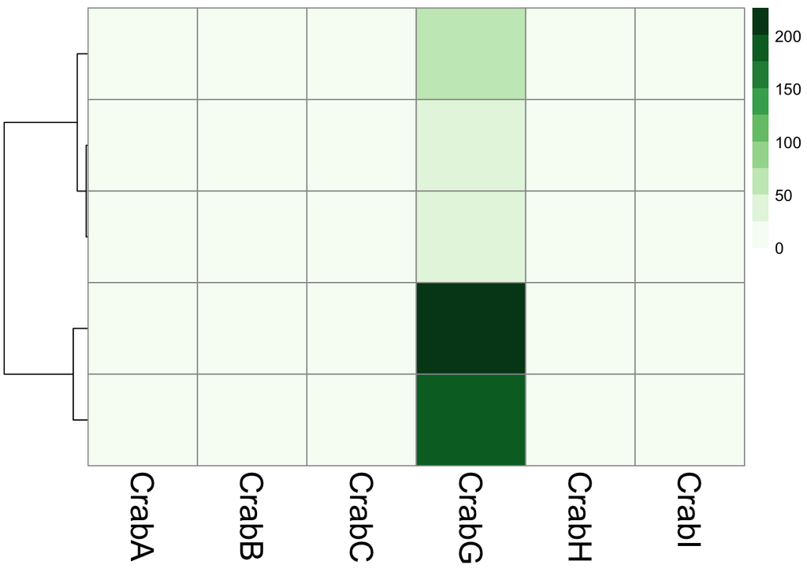

```r
pheatmap(abcghi_nmcts.heatmap.sub, cluster_row = TRUE, cluster_cols = FALSE, clustering_distance_rows = "euclidean", clustering_method = "average", show_rownames = FALSE, show_colnames = TRUE, treeheight_col = 80, legend = TRUE, color = heatmapGreens, fontsize_col = 20, fontsize_row = 12)
```